# Data training questions

Hannah’s revamped training questions

Cian Luck

22 July 2021

WORK IN PROGRESS

# Setup

Load packages

```r
library(tidyverse)
library(bigrquery)
library(DBI)
library(fishwatchr)
library(glue)
library(lubridate)
library(here)
library(sf)
```

Establish connection to Big Query project

```r
con <- DBI::dbConnect(drv = bigrquery::bigquery(),
                      project = "world-fishing-827",
                      use_legacy_sql = FALSE)
```

# Fishing inspection

## 1. Plot a map of the track and fishing by the vessel with the MMSI 367650000

Point to the saved .sql file in 00_queries

```r
# query_3 <- readr::read_file(file = here::here("queries/cian_queries", "cianluck-track-367650000.sql"))

query_3 <- glue_sql(
  "
###########################################################
#QUERY: Fishing effort by MMSI 367650000 between
# 01 Mar 2017 and 05 Mar 2017

WITH

  ########################################
  # This subquery identifies good segments
  good_segments AS (
  SELECT
    seg_id
  FROM
    `gfw_research.pipe_v20201001_segs`
  WHERE
    good_seg
    AND positions > 10
    AND NOT overlapping_and_short),

  ####################################################################
  # Get the list of active fishing vessels that pass the noise filters
  vessel AS (
  SELECT
    ssvid,
    ais_identity.shipname_mostcommon.value as shipname,
    best.best_flag,
    best.best_vessel_class as vessel_class,
    year
  FROM gfw_research.vi_ssvid_byyear_v20210706
  WHERE ssvid = '367650000'
  ),

  #####################################################################
  # This subquery fishing query gets all positions between 01 Mar 2017 and 05 Mar 2017
  # It queries the pipe_vYYYYMMDD_fishing table, which includes only likely
  # fishing vessels.
  fishing AS (
      SELECT
      ssvid,
      lat,
      lon,
      nnet_score,
      timestamp,
      hours,
      night_loitering,
      # Get the year for filtering with the list of active fishing vessels
      EXTRACT(year from timestamp) as year,
    FROM
      # Query the pipe_vYYYYMMDD_fishing table since we're only
      # interested in likely fishing vessels. This reduces query size.
      `world-fishing-827.gfw_research.pipe_v20201001_fishing`
    WHERE
        DATE(_PARTITIONTIME) BETWEEN '2017-03-01' AND '2017-03-05'
    AND seg_id IN (
      SELECT
        seg_id
      FROM
        good_segments)),

  ########################################################################
  # Filter fishing to just the list of active fishing vessels in that year
  fishing_filtered AS (
  SELECT *
  FROM fishing
  JOIN vessel
  # Only keep positions for fishing vessels active that year
  USING(ssvid, year)
  ),

  ########################################################################
  # Use nnet_score to identify fishing activity for all vessel_class except
  # squid jiggers, for which we use night_loitering instead
  fishing_hours_filtered AS (
      SELECT
      *,
      # Calculate fishing hours by evaluating neural net score
      # If the neural net score is >0.5, fishing hours are equal
      # to hours, else set fishing hours to 0
      CASE
        WHEN vessel_class = 'squid_jigger' and night_loitering = 1 THEN hours
        WHEN vessel_class != 'squid_jigger' and nnet_score > 0.5 THEN hours
      ELSE 0
    END
    AS fishing_hours
    FROM fishing_filtered
  )



#####################
# Return fishing data
SELECT *
FROM fishing_hours_filtered
  "
)
```

Run the query using `fishwatchr::gfw_query()`

```r
track_367_df <- fishwatchr::gfw_query(query = query_3,
                                     run_query = TRUE,
                                     con = con)$data
```

```
[1] "Running query..."
```

```r
saveRDS(track_367_df, "data_production/367650000_no_filters.rds")
```

```r
fishing_track_review(track_df = track_367_df,
                     color_fishing = TRUE,
                     globe_location = 'lowerright',
                     time_series_labels = c('speed_knots','depth_m','distance_from_shore_km'))
```

[output not shown]

This query returns an empty dataframe. Either there’s an issue with my query (most likely, but haven’t figured it out yet) or the vessel wasn’t active during this period?

I had better luck extracting a track for the vessel with ssvid 432346000, which was the previous iteration of this question. Here’s a track of that vessel for the sake of practice.

Read in previously saved data

```r
track_43_df <- read_rds("data_production/432346000_no_filters.rds")
```

Map of track and fishing locations

Quick map for inspecting the track data

```
although coordinates are longitude/latitude, st_union assumes that they are planar
although coordinates are longitude/latitude, st_union assumes that they are planar
dist is assumed to be in decimal degrees (arc_degrees).
although coordinates are longitude/latitude, st_intersection assumes that they are planar
```

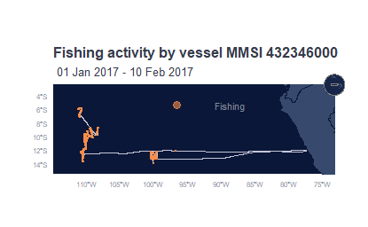

```r
bounding <- transform_box(xlim = c(-113, -75),
                          ylim = c(-15, -3),
                          output_crs = "+proj=longlat +ellps=WGS84 +datum=WGS84 +no_defs")


map_43 <- track_43_df %>%
  group_by(ssvid) %>%
  arrange(timestamp) %>%
ggplot() +
  geom_path(aes(x = lon, y = lat, group = factor(ssvid)), colour = gfw_palette("blue")[5]) +
  scale_colour_manual(values = gfw_palette("blue")[5]) +
  geom_point(data = track_43_df %>% filter(fishing_hours > 0),
             aes(x = lon, y = lat, colour = "Fishing"), size = 0.5, alpha = 0.6) +
  scale_colour_manual(values = gfw_palette("orange")[1], name = NULL) +
  labs(title = "Fishing activity by vessel MMSI 432346000",
          subtitle = " 01 Jan 2017 - 10 Feb 2017") +
  geom_gfw_land() +
  # geom_gfw_eez() +
  guides(colour = guide_legend(override.aes = list(size = 3))) +
  theme_gfw_map_cian() +
  theme(plot.title.position = "panel",
        plot.title = element_text(hjust = 0, size = 12),
        panel.grid = element_blank(),
        panel.grid.major = element_blank(),
        panel.grid.minor = element_blank(),
        legend.position = c(0.5,0.8),
        legend.text.align = 0) +
  coord_sf(xlim = c(bounding$box_out[['xmin']], bounding$box_out[['xmax']]),
           ylim = c(bounding$box_out[['ymin']], bounding$box_out[['ymax']]),
           crs = bounding$out_crs)
add_little_globe(main_map = map_43,
                 main_box = bounding,
                 globe_rel_size = 0.4,
                 globe_just = 'center',
                 globe_position = 'upperright')
```

## 2. How many hours of fishing are estimated during this time?

467.96 hours total - in reference to vessel ssvid 432346000.

## 3. What type of fishing vessel is it?

I was able to extract the vessel info for ssvid 367650000.

```r
# query_4 <- readr::read_file(file = here::here("queries/cian_queries", "cianluck-vi-367650000.sql"))

query_4 <- glue_sql(
  "
  SELECT
    ssvid,
    year,
    best.best_vessel_class,
    registry_info.registries_listed,
    registry_info.best_known_imo,
    registry_info.best_known_callsign,
    registry_info.best_known_flag
  FROM gfw_research.vi_ssvid_byyear_v20210706
  WHERE ssvid = '367650000'
    AND year = 2017
  "
)
```

Run the query using `fishwatchr::gfw_query()`

```r
vi_36_df <- fishwatchr::gfw_query(query = query_4,
                                  run_query = TRUE,
                                  con = con)$data
```

The vessel is a **trawlers**.

## 4. Provide the other vessel identity information and registry records during this time

```r
knitr::kable(vi_36_df)
```

| ssvid | year | best_vessel_class | registries_listed | best_known_imo | best_known_callsign | best_known_flag |
| --- | --- | --- | --- | --- | --- | --- |
| 367650000 | 2017 | trawlers | NEPAC, REV , USA | 7933555 | WDF7174 | USA |

## 5. Plot a raster of all fishing by Chinese flagged squid jiggers in NPFC in 2018.

```r
# query_5 <- readr::read_file(file = here::here("queries/cian_queries", "cianluck-chinese-squid-jiggers-gridded-effort-npfc-2018.sql"))

query_5 <- glue_sql(
  "
  WITH

  ########################################
  # This subquery identifies good segments
  good_segments AS (
  SELECT
    seg_id
  FROM
    `gfw_research.pipe_v20201001_segs`
  WHERE
    good_seg
    AND positions > 10
    AND NOT overlapping_and_short),

  ####################################################################
  # Get the list of active fishing vessels that pass the noise filters
  fishing_vessels AS (
  SELECT
    ssvid,
    year,
    best_flag,
    best_vessel_class
  FROM
    `gfw_research.fishing_vessels_ssvid_v20210706`
  WHERE
    best_flag = 'CHN' AND
    best_vessel_class = 'squid_jigger'
  ),

  #####################################################################
  # This subquery fishing query gets all fishing on November 20th, 2018
  # It queries the pipe_vYYYYMMDD_fishing table, which includes only likely
  # fishing vessels. However, we are not fully confident in all vessels on
  # this list and the table also includes noisy vessels. Thus, analyses
  # often filter the pipe_vYYYYMMDD_fishing table to a refined set of vessels
  fishing AS (
  SELECT
    ssvid,
    lat,
    lon,
    /*
    Assign lat/lon bins at desired resolution (here 10th degree)
    FLOOR takes the smallest integer after converting to units of
    0.1 degree - e.g. 37.42 becomes 374 10th degree units
    */
    FLOOR(lat * 10) as lat_bin,
    FLOOR(lon * 10) as lon_bin,
    EXTRACT(date FROM _partitiontime) as date,
    EXTRACT(year FROM _partitiontime) as year,
    hours,
    nnet_score,
    night_loitering
  /*
  Query the pipe_vYYYYMMDD_fishing table to reduce query
  size since we are only interested in fishing vessels
  */
  FROM
    `gfw_research.pipe_v20201001_fishing`
  # Restrict query to specific time range
  WHERE _partitiontime BETWEEN '2018-01-01' AND '2018-12-31'
  # Use good_segments subquery to only include positions from good segments
  AND seg_id IN (
    SELECT
      seg_id
    FROM
      good_segments)),


  ########################################################################
  # Filter fishing to just the list of active fishing vessels in that year
  fishing_filtered AS (
  SELECT *
  FROM fishing
  JOIN fishing_vessels
  # Only keep positions for fishing vessels active that year
  USING(ssvid, year)
  ),

   ########################################################################
  # Read in shapefile of npfc
  npfc AS (
    SELECT
        ST_GEOGFROMTEXT(string_field_1) AS polygon
    FROM
        `world-fishing-827.ocean_shapefiles_all_purpose.NPFC_shape`
    ),

  ########################################################################
  # Filter fishing to only include activity within the npfc
  fishing_in_npfc AS (
    SELECT
      *
    FROM
      fishing_filtered
    WHERE
    IF
      (ST_CONTAINS( (
          SELECT
            polygon
          FROM
            npfc),
          ST_GEOGPOINT(lon, lat)),
        TRUE,
        FALSE)
    ),

  ########################################################################
  # Create fishing_hours attribute. Use night_loitering instead of nnet_score as indicator of fishing for squid jiggers
  fishing_hours_filtered AS (
  SELECT *,
    CASE
      WHEN best_vessel_class = 'squid_jigger' and night_loitering = 1 THEN hours
      WHEN best_vessel_class != 'squid_jigger' and nnet_score > 0.5 THEN hours
      ELSE 0
    END
    AS fishing_hours
  FROM fishing_in_npfc
  ),

  #####################################################################
  # This subquery sums fishing hours and converts coordinates back to
  # decimal degrees
  fishing_binned AS (
  SELECT
    date,
    /*
    Convert lat/lon bins to units of degrees from 10th of degrees.
    374 now becomes 37.4 instead of the original 37.42
    */
    lat_bin / 10 as lat_bin,
    lon_bin / 10 as lon_bin,
    best_vessel_class,
    best_flag,
    SUM(hours) as hours,
    SUM(fishing_hours) as fishing_hours
  FROM fishing_hours_filtered
  GROUP BY date, lat_bin, lon_bin, best_vessel_class, best_flag
  )

#####################
# Return fishing data
SELECT *
FROM fishing_binned
  "
)
```

```r
eff_chn_squid <- fishwatchr::gfw_query(query = query_5,
                                  run_query = TRUE,
                                  con = con)$data
```

Map

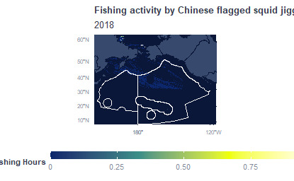

```r
bounding_npfc <- transform_box(xlim = c(-120, 150),
                            ylim = c(10, 70),
                            output_crs = gfw_projections("North Pacific")$proj_string)


eff_chn_squid %>%
  recenter_raster(raster_df = .,
                  res = 1,
                  x_lab = "lon_bin",
                  y_lab = "lat_bin",
                  fill_lab = "fishing_hours",
                  center = 180,
                  proj = "+proj=eqearth +lon_0=0 +wktext") %>%
  ggplot() +
  geom_raster(aes(x = lon_bin,
                  y = lat_bin,
                  fill = fishing_hours)) +
  geom_sf(data = npfc_sf, colour = "white", fill = NA) +
  # geom_gfw_land(center = 180) +
  geom_gfw_land() +
  labs(title = "Fishing activity by Chinese flagged squid jiggers",
       subtitle = "2018") +
  scale_fill_gradientn(colours = gfw_palette("map_effort_dark"),
                       limits = c(0,1),
                       labels = c("0","0.25","0.50","0.75",">1.00"),
                       oob = scales::squish,
                       na.value = NA,
                       name = "Fishing Hours") +
  theme_gfw_map_cian() +
  coord_sf(xlim = c(bounding_npfc$box_out[['xmin']], bounding_npfc$box_out[['xmax']]),
           ylim = c(bounding_npfc$box_out[['ymin']], bounding_npfc$box_out[['ymax']]),
           crs = bounding_npfc$out_crs)
```

So I’m clearly having a bit of a battle with my projections here. I’m still working on it, but any tips greatly appreciated.